# NBA Performance and Impacts Analytics Dashboard

## Initial Loading

```r
library("dplyr")
library("ggplot2")
library("infer")
```

## Visualization Analysis

The purpose of this component of the project is to analyze variables and look for trends or factors that may impact player and team performance in basketball. Exploration of data is more focused on in this component than in-depth analysis, which will be focused on in later components that rely on the findings in this component.

###Boxplots (Team-Level Analysis)

Boxplots are used to compare summary statistic of key variables amongst all teams

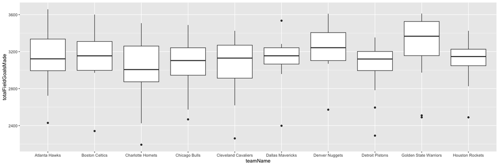

```r
#Since there are 30 teams, to make visualizations more readable, 3 side-by-side boxplots will be used. The y-scales will also be monitored closely, since there will be 3 boxplots with different scales.
#Charlotte Hornets data was used instead of Charlotte Bobcats since it is the newer name for the team

#Field Goals Made
regular_season_field_goals_boxplot_1<-regular_season_team_summary_stats|>
                                             filter(teamName %in% c("Atlanta Hawks","Boston Celtics","Charlotte Hornets","Chicago Bulls",
                                                                    "Cleveland Cavaliers","Dallas Mavericks","Denver Nuggets","Detroit Pistons",
                                                                    "Golden State Warriors","Houston Rockets"))|>
                                             ggplot() +
                                             geom_boxplot(aes(x=teamName,y=totalFieldGoalsMade))

regular_season_field_goals_boxplot_2<-regular_season_team_summary_stats|>
                                             filter(teamName %in% c("Indiana Pacers","Los Angeles Clippers","Los Angeles Lakers",
                                                                    "Memphis Grizzlies","Miami Heat","Milwaukee Bucks",
                                                                    "Minnesota Timberwolves","Brooklyn Nets",
                                                                    "New Orleans Pelicans", "New York Knicks"))|>
                                             ggplot() +
                                             geom_boxplot(aes(x=teamName,y=totalFieldGoalsMade))

regular_season_field_goals_boxplot_3<-regular_season_team_summary_stats|>
                                             filter(teamName %in% c("Oklahoma City Thunder","Orlando Magic","Phoenix Suns",
                                                                    "Portland Trail Blazers","Sacramento Kings",
                                                                    "San Antonio Spurs","Toronto Raptors",
                                                                    "Washington Wizards","Philadelphia 76ers","Utah Jazz"))|>
                                             ggplot() +
                                             geom_boxplot(aes(x=teamName,y=totalFieldGoalsMade))

regular_season_field_goals_boxplot_1
```

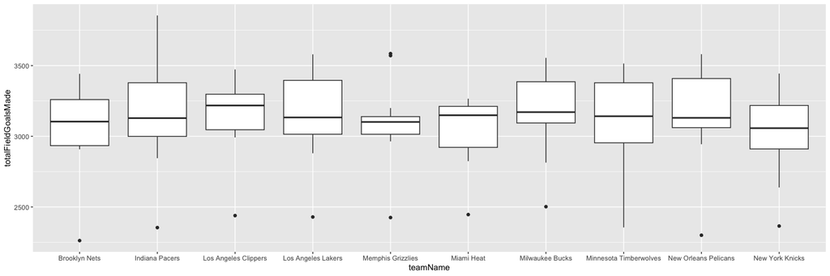

```r
regular_season_field_goals_boxplot_2
```

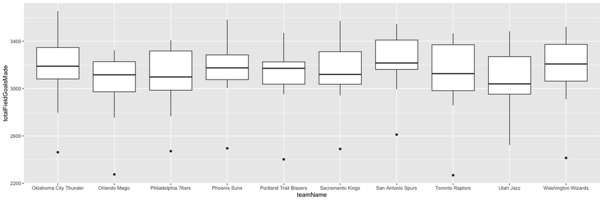

```r
regular_season_field_goals_boxplot_3
```

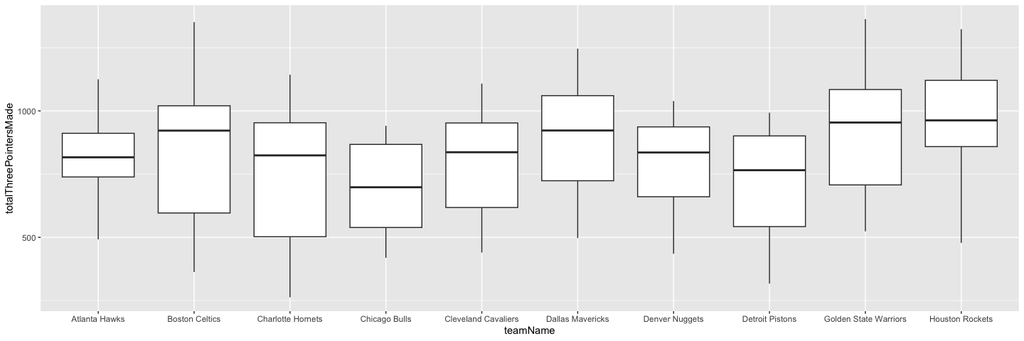

```r
#Three Pointers Made
regular_season_three_pointers_boxplot_1<-regular_season_team_summary_stats|>
                                             filter(teamName %in% c("Atlanta Hawks","Boston Celtics","Charlotte Hornets","Chicago Bulls",
                                                                    "Cleveland Cavaliers","Dallas Mavericks","Denver Nuggets","Detroit Pistons",
                                                                    "Golden State Warriors","Houston Rockets"))|>
                                             ggplot() +
                                             geom_boxplot(aes(x=teamName,y=totalThreePointersMade))

regular_season_three_pointers_boxplot_2<-regular_season_team_summary_stats|>
                                             filter(teamName %in% c("Indiana Pacers","Los Angeles Clippers","Los Angeles Lakers",
                                                                    "Memphis Grizzlies","Miami Heat","Milwaukee Bucks",
                                                                    "Minnesota Timberwolves","New Jersey Nets",
                                                                    "New Orleans Pelicans", "New York Knicks"))|>
                                             ggplot() +
                                             geom_boxplot(aes(x=teamName,y=totalThreePointersMade))

regular_season_three_pointers_boxplot_3<-regular_season_team_summary_stats|>
                                             filter(teamName %in% c("Oklahoma City Thunder","Orlando Magic","Phoenix Suns",
                                                                    "Portland Trail Blazers","Sacramento Kings",
                                                                    "San Antonio Spurs","Toronto Raptors",
                                                                    "Washington Wizards","Philadelphia 76ers","Utah Jazz"))|>
                                             ggplot() +
                                             geom_boxplot(aes(x=teamName,y=totalThreePointersMade))

regular_season_three_pointers_boxplot_1
```

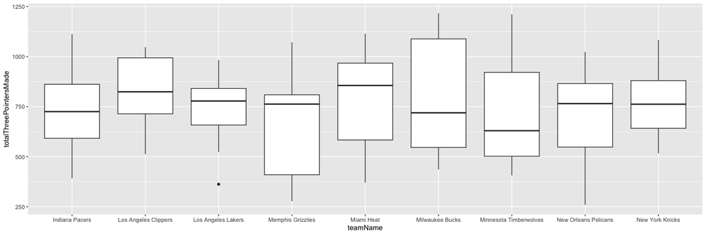

```r
regular_season_three_pointers_boxplot_2
```

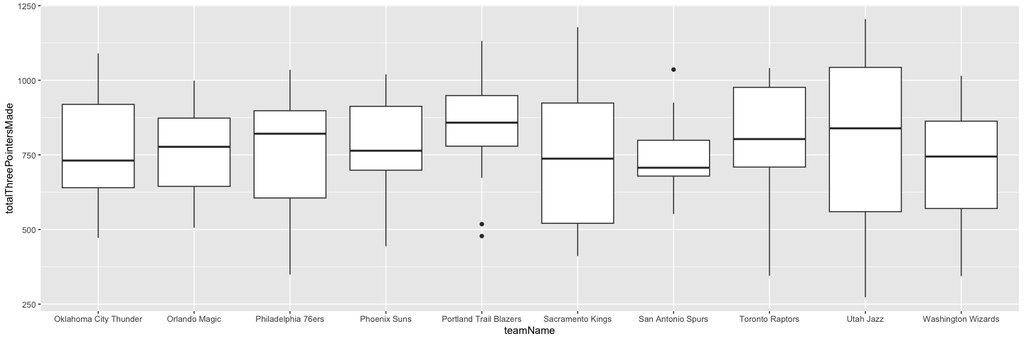

```r
regular_season_three_pointers_boxplot_3
```

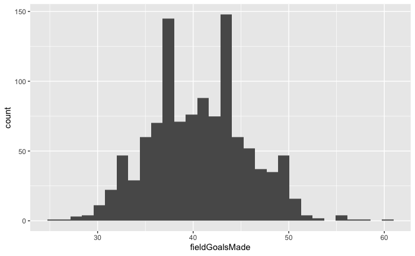

```r
regular_season_totals|>filter(teamName=="San Antonio Spurs")|>ggplot(aes(x=fieldGoalsMade)) + geom_histogram()
```

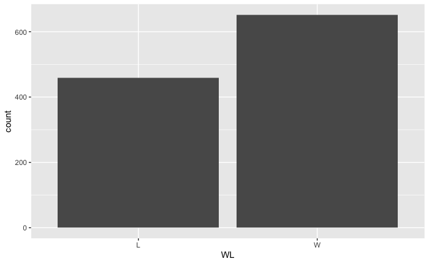

```r
regular_season_totals|>filter(teamName=="San Antonio Spurs")|>ggplot(aes(x=WL)) + geom_bar()
```

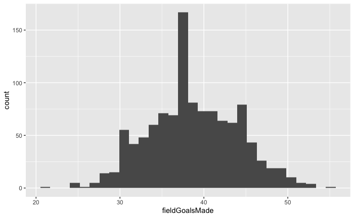

```r
regular_season_totals|>filter(teamName=="Utah Jazz")|>ggplot(aes(x=fieldGoalsMade)) + geom_histogram()
```

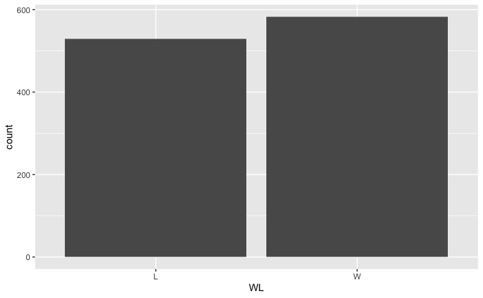

```r
regular_season_totals|>filter(teamName=="Utah Jazz")|>ggplot(aes(x=WL)) + geom_bar()
```

```r
regular_season_team_all_time_summary_stats|>filter(teamName=="Utah Jazz" | teamName=="San Antonio Spurs" )
```

| teamName | totalWins | avgWins | totalLosses | avgLosses | winPercentage | totalMinutesPlayed | avgMinutesPlayed | totalFieldGoalsAttempted | avgFieldGoalsAttempted | totalFieldGoalsMade | avgFieldGoalsMade | sdFieldGoalsMade | totalFieldGoalsPercentage | avgFieldGoalsPercentage | sdFieldGoalsPercentage | totalThreePointersMade | avgThreePointersMade | sdThreePointersMade | totalThreePointersAttempted | avgThreePointersAttempted | totalThreePointersPercentage | avgThreePointersPercentage | sdThreePointersPercentage | totalFreeThrowsMade | avgFreeThrowsMade | sdFreeThrowsMade | totalFreeThrowsAttempted | avgFreeThrowsAttempted | totalFreeThrowsPercentage | … |
| --- | --- | --- | --- | --- | --- | --- | --- | --- | --- | --- | --- | --- | --- | --- | --- | --- | --- | --- | --- | --- | --- | --- | --- | --- | --- | --- | --- | --- | --- | --- |
| San Antonio Spurs | 652 | 0.5868587 | 459 | 0.4131413 | 1.420479 | 53708 | 48.34203 | 95870 | 86.29163 | 45210 | 40.69307 | 5.158072 | 0.4715761 | 0.4729442 | 0.05564821 | 10454 | 9.409541 | 3.430213 | 28309 | 28309 | 0.3692819 | 0.3725635 | 0.1037649 | 18560 | 16.70567 | 5.655322 | 23742 | 21.36994 | 0.7817370 | … |
| Utah Jazz | 583 | 0.5242806 | 529 | 0.4757194 | 1.102079 | 53736 | 48.32374 | 93239 | 83.84802 | 43039 | 38.70414 | 5.308626 | 0.4615987 | 0.4622149 | 0.05343936 | 11247 | 10.114209 | 4.852876 | 31177 | 31177 | 0.3607467 | 0.3554595 | 0.0970901 | 19799 | 17.80486 | 5.837328 | 25873 | 23.26709 | 0.7652379 | … |

```r
NA
NA
```

The histograms and bar charts above show that the San Antonio Spurs have a roughly larger average of field goals made while also more wins than Utah Jazz. To further explore how field goals made are associated with wins, a 95% confidence interval for the difference in mean field goals made is computed by bootstrapping 1000 resamples from all 49 NBA games during 2010-2024 with San Antonio Spurs and Utah Jazz as the matchup.

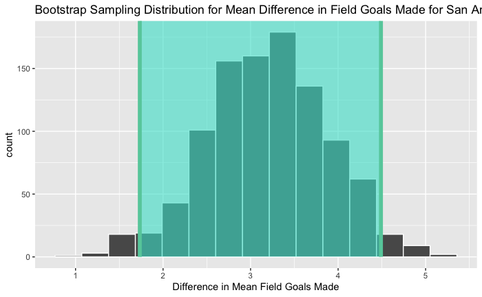

```r
winning_games<-regular_season_totals|>filter(WL=="W")
losing_games<-regular_season_totals|>filter(WL=="L")

combined_games<-merge(winning_games,losing_games,by="gameId")|>mutate(diffFieldGoalsMade=fieldGoalsMade.x-fieldGoalsMade.y)

sas_uta_games<-filter(combined_games,(teamName.x=="San Antonio Spurs" & teamName.y=="Utah Jazz") | (teamName.x=="Utah Jazz" & teamName.y=="San Antonio Spurs"))

sas_uta_field_goals_bootstrap_distribution<-sas_uta_games|>specify(response=diffFieldGoalsMade)|>generate(reps=1000,type="bootstrap")|>calculate(stat="mean")

sas_uta_percentile_confidence_interval<-sas_uta_field_goals_bootstrap_distribution|>get_confidence_interval(level=0.95,type="percentile")

sas_uta_field_goals_confidence_interval<-visualize(sas_uta_field_goals_bootstrap_distribution)+shade_confidence_interval(endpoints=sas_uta_percentile_confidence_interval) +
                                 labs(x="Difference in Mean Field Goals Made",title="Bootstrap Sampling Distribution for Mean Difference in Field Goals Made for San Antonio Spurs vs. Utah Jazz (n=1000)")

sas_uta_field_goals_confidence_interval
```

```r
sas_uta_percentile_confidence_interval
```

| lower_ci | upper_ci |
| --- | --- |
| 1.734184 | 4.489796 |

Based on the interval, 95% of sample sizes of 49 games will produce a 95% confidence interval that contains the true mean difference in field goals made betwen the San Antonio Spurs and Utah Jazz. In other words, there is 95% confidence that the true mean difference in field goals made between the San Antonio Spurs and Utah Jazz lies between approximately 1.73 and 4.49 field goals. Given that the interval ranges above a 1.5 difference in field goals made, such phenomenon further supports the suggestion that field goals made are a key factor to winning basketball games. To further explore this suggestion, a 95% confidence interval is computed for the entire sample of NBA games.

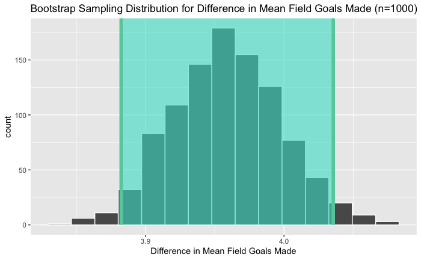

```r
field_goals_bootstrap_distribution<-combined_games|>specify(response=diffFieldGoalsMade)|>generate(reps=1000,type="bootstrap")|>calculate(stat="mean")

percentile_confidence_interval<-field_goals_bootstrap_distribution|>get_confidence_interval(level=0.95,type="percentile")

field_goals_confidence_interval<-visualize(field_goals_bootstrap_distribution)+shade_confidence_interval(endpoints=percentile_confidence_interval) +
                                 labs(x="Difference in Mean Field Goals Made",title="Bootstrap Sampling Distribution for Difference in Mean Field Goals Made (n=1000)")

field_goals_confidence_interval
```

```r
percentile_confidence_interval
```

| lower_ci | upper_ci |
| --- | --- |
| 3.882337 | 4.035609 |

```r
df <- 16658  # degrees of freedom

x <- seq(-4, 4, length.out = 1000)  # x-axis values covering typical range
y <- dt(x, df = df)  # t-distribution density values

plot(x, y, type = "l", lwd = 2, col = "blue",
     main = paste("t-distribution with", df, "degrees of freedom"),
     ylab = "Density", xlab = "t")
```

[output not shown]

```r
ggplot(z, aes(x = diff, y = WL)) +
      geom_point() + # Plot the point estimates
      geom_errorbar(aes(xmin = lower_ci, ymax = upper_ci), width = 0.2) + # Add error bars
      labs(title = "Mean with 95% Confidence Intervals",
           x = "Group", y = "Mean Value") +
      theme_minimal()
```

[output not shown]

```r
x_vals<-seq(min(z$diff)-1,max(z$diff)+1,length.out=500)
t_density<-dt(x_vals,df=16657)
plot(x_vals,t_density,type="l",col="blue",lwd=2,main=paste("T-Distribution (df=",16657,") and Data Density"),xlab="Value",ylab="Density")
lines(density(x_vals),col="red",lwd=2,lty=2)
```

[output not shown]

```r
ggplot(z, aes(x = diff)) +
  geom_histogram(bins = 50, fill = "lightblue", color = "black", alpha = 0.7) +
  geom_vline(xintercept = mean(z$diff), color = "blue", size = 1.2) +   # sample mean
  geom_rect(aes(xmin = 3.88, xmax = 4.03, ymin = 0, ymax = Inf),
            fill = "orange", alpha = 0.3, inherit.aes = FALSE) +
  labs(title = "Histogram of Differences with 95% Confidence Interval",
       x = "Difference",
       y = "Count") +
  theme_minimal()
```

[output not shown]

```r
mean_diff <- mean(z$diff)
sd_diff <- sd(z$diff)
n <- length(z$diff)
se_diff <- sd_diff / sqrt(n)

z_star <- qnorm(0.975)
lower <- mean_diff - z_star * se_diff
upper <- mean_diff + z_star * se_diff

ggplot(z, aes(x = diff)) +
  geom_histogram(bins = 50, fill = "lightblue", color = "black", alpha = 0.7) +
  geom_vline(xintercept = mean_diff, color = "blue", size = 1.2, linetype = "solid") +    # mean line
  geom_vline(xintercept = lower, color = "red", linetype = "dashed") +                   # lower CI
  geom_vline(xintercept = upper, color = "red", linetype = "dashed") +                   # upper CI
  labs(title = "Histogram of Differences with 95% Confidence Interval for the Mean",
       x = "Difference",
       y = "Count") +
  theme_minimal()
```

[output not shown]

```r
mean_estimate <- 10
standard_error <- 2
conf_level <- 0.95
alpha <- 1 - conf_level

# Critical z-value
z <- qnorm(1 - alpha/2)

# Confidence interval limits
lower <- mean_estimate - z * standard_error
upper <- mean_estimate + z * standard_error


df <- data.frame(
  x = 1,
  estimate = mean_estimate,
  lower = lower,
  upper = upper
)

ggplot(df, aes(x = factor(x), y = estimate)) +
  geom_point(size = 3) +
  geom_errorbar(aes(ymin = lower, ymax = upper), width = 0.2) +
  labs(x = "", y = "Estimate with 95% CI") +
  theme_minimal()
```

[output not shown]

```r
qt(0.025,df=16657,lower.tail=TRUE)
qnorm(0.025,mean=0,sd=1,lower.tail=TRUE)
```

[output not shown]

## Correlation Data

Correlations between variables of player statistics and team statistics, all time.

```r
#Correlations by team statistics, all time

regular_season_team_correlations<-regular_season_totals|>select(fieldGoalsMade,fieldGoalsAttempted,
                                                                threePointersMade,threePointersAttempted,
                                                                freeThrowsMade,freeThrowsAttempted,
                                                                reboundsOffensive,reboundsDefensive,
                                                                reboundsTotal,assists,turnovers,
                                                                steals,turnovers,steals,blocks,
                                                                opponentBlocks,foulsPersonal,
                                                                foulsPersonalDrawn,points)|>
                                                          cor()

play_off_team_correlations<-play_off_totals|>select(fieldGoalsMade,fieldGoalsAttempted,
                                                                threePointersMade,threePointersAttempted,
                                                                freeThrowsMade,freeThrowsAttempted,
                                                                reboundsOffensive,reboundsDefensive,
                                                                reboundsTotal,assists,turnovers,
                                                                steals,turnovers,steals,blocks,
                                                                opponentBlocks,foulsPersonal,
                                                                foulsPersonalDrawn,points)|>
                                                          cor()

#Correlations by player statistics, all time

regular_season_player_correlations<-regular_season_box_scores|>
                                    select(fieldGoalsMade,fieldGoalsAttempted,
                                           threePointersMade,threePointersAttempted,
                                           freeThrowsMade,freeThrowsAttempted,
                                           reboundsOffensive,reboundsDefensive,
                                           reboundsTotal,assists,turnovers,
                                           steals,turnovers,steals,blocks,
                                           foulsPersonal,points)|>
                                    cor()

play_off_player_correlations<-play_off_box_scores|>
                              select(fieldGoalsMade,fieldGoalsAttempted,
                                     threePointersMade,threePointersAttempted,
                                     freeThrowsMade,freeThrowsAttempted,
                                     reboundsOffensive,reboundsDefensive,
                                     reboundsTotal,assists,turnovers,
                                     steals,turnovers,steals,blocks,
                                     foulsPersonal,points)|>
                               cor()

regular_season_team_correlations
play_off_team_correlations
regular_season_player_correlations
play_off_player_correlations
```

[output not shown]

```r
x<-regular_season_totals|>filter(WL=="W")
y<-regular_season_totals|>filter(WL=="L")

z<-merge(x,y,by="gameId")




x_mean<-x|>summarise(avgFieldGoals=mean(fieldGoalsMade),sdFieldGoals=sd(fieldGoalsMade))
y_mean<-y|>summarise(avgFieldGoals=mean(fieldGoalsMade),sdFieldGoals=sd(fieldGoalsMade))
x_mean
y_mean
x
y

z<-z|>mutate(diff=fieldGoalsMade.x-fieldGoalsMade.y)
sd(z$diff)
hist(z$diff,breaks=50)
regular_season_box_scores

t.test(z$fieldGoalsMade.x,z$fieldGoalsMade.y,paired=TRUE,alternative="less")
qt(0.975,df=16658)
```

[output not shown]